# Data Analysis - Final Exam 2023

Author

Maik Bieleke & Johanna Stähler

## Directions

### Article

This exam is based on Weigl, K., Schuster, S., & Riener, A. (2021). Investigation of UX and flow experience in sports activities during the covid-19 pandemic: A comparative analysis of cycling apps. In *Proceedings of the 9th International Conference on Sport Sciences Research and Technology Support*, p. 61-68. http://dx.doi.org/10.5220/0010688200003059

Both the article (`Weigl2021.pdf`) and the data (`Weigl2021.csv`) are available on Ilias. You should read the paper carefully before working on the exam. Make sure that you understand the methods and analyses, as well as the dataset.

### Scoring

The maximum possible score for the exam is 100 points. Up to 90 points can be earned by solving the six problems. Another 10 points can be earned by adhering to the coding and scripting style introduced in the seminar.

| Problem | Points |
| --- | --- |
| Problem 1 | 10 |
| Problem 2 | 10 |
| Problem 3 | 15 |
| Problem 4 | 15 |
| Problem 5 | 25 |
| Problem 6 | 15 |
| Coding & Scripting Style | 10 |

### Packages and functions

If not explicitly stated otherwise in the problem, only R packages, R functions, and RStudio features introduced in the seminar are allowed for solving the problems. You will receive 0 points for a task that uses other packages, functions, or features.

### Referencing seminar content

Whenever you use or mention R packages, R functions, or RStudio features from the seminar, provide a brief reference to the relevant lecture slide (e.g., L1 - Introduction to L6 - Analysis, Slide XX). You will receive 0 points for a task that has no proper references.

Example: Calculate the mean and standard deviation of vector A.

Answer:

```r
# L4, Slide 5
mean(vectorA)
sd(vectorA)
```

### Files

You submit four files: * The analysis script. * The text document (e.g., `.docx`) with detailed explanations and descriptions. * The screenshot from Problem 1. * The figure from Problem 5.

## Problem 1: Data preprocessing (10 points)

Note that this problem deals with the original dataset provided by the authors, not with the dataset you received for the exam. Accordingly, all answers can be provided in the text document even if it involves R code.

Figure 1 shows a screenshot that has been generated based on the original dataset provided by the authors.

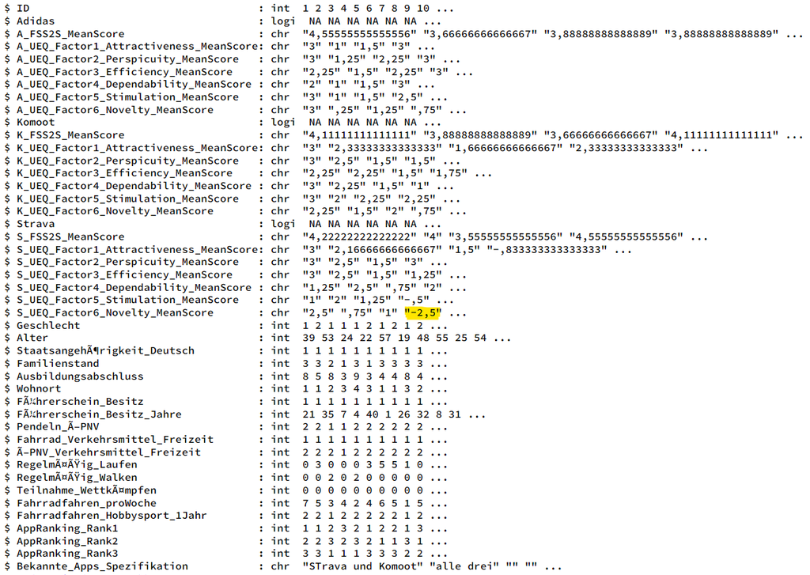

Figure 1: Screenshot based on the original dataset

1. Explain in writing what output the screenshot displays, and what information it provides about the data.
2. Identify 5 potential issues with the data shown in the screenshot. Describe in writing how each issue can be addressed, and specify the R functions involved (plus references to seminar slides and exercises)
3. One value in the screenshot is highlighted in yellow. Suggest six ways of extracting the value using functions and operations introduced in the seminar. Provide the code for each approach along with a brief explanation of how it works.

## Problem 2: Analysis workflow (10 points)

Note that no R coding is required for solving the following tasks.

1. Establish a data analysis workflow along the guidelines provided in the seminar, using RStudio features only. Your workflow should involve creating a directory with all the files and folders needed for the analysis at hand.
2. Describe in writing how you established the directory in RStudio. Produce a screenshot (or take a picture) of the appropriate RStudio pane or tab that shows your directory.
3. Explain in writing how your workflow handles the working directory and the workspace for your analysis.

In the following, import data, export outputs, load packages, etc. as necessary for solving the problems.

## Problem 3: Demographic variables (15 points)

In this problem, you will analyze some of the demographic variables in the paper. Make sure that your output closely matches the output shown below, which might require preprocessing the variables. Note that character functions (Lecture 4, Slide 9ff) are neither necessary nor allowed for solving this problem.

1. Gender: Absolute frequency of women and men

   ```
   women   men
      20    14
   ```

2. Gender: Relative frequency of women and men.

   ```
   women   men
   58.82 41.18
   ```

3. Age: Means, standard deviations, and ranges for women and men.

   ```
   # A tibble: 2 x 5
     sex     Min   Max     M    SD
     <fct> <int> <int> <dbl> <dbl>
   1 women    19    57  32.5  13.3
   2 men      19    56  39.5  13.3
   ```

4. The authors reported how many of their participants “regularly go running (12/34)” (p. 62). Find the relevant variable in the dataset and reconstruct how the authors arrive at these numbers. Then modify and analyze the variable to produce the following output.

   ```
   no regular running    regular running
                   22                 12
   ```

5. The authors claim that 18 participants knew at least one of the three apps. Find the relevant variable in the dataset and use R code to demonstrate that this statement is incorrect.

Several Cronbach’s $\alpha$ values are reported in the article. Cronbach’s $\alpha$ is a measure of the internal consistency of a scale. One way to compute it in R is the `misty::item.alpha()` function. Solve the following tasks based on the function’s documentation.

1. Show that the Cronbach’s $\alpha$ values reported in the article cannot be calculated with the available dataset according to the documentation.
2. What additional data would allow to calculate the values according to the documentation? Describe two possibilities.
3. Write code that could be used to calculate the standardized Cronbach’s $\alpha$ if this additional data were available.
4. Change your code to compute the standardized McDonald’s $\omega$, which is an alternative measure of the internal consistency of a scale.
5. Compute Cronbach’s $\alpha$ and McDonald’s $\omega$ using the example data in the documentation of `misty::item.alpha()`. Extract the two values from the output to produce the following console output without typing the values manually. Explain your approach with reference to the corresponding slides and exercises from the seminar.

   ```
   Coefficient alpha is 0.88 and coefficient omega is 0.88 as well.
   ```

## Problem 5: Visualizing the User Experience Questionnaire (UEQ) (25 points)

The authors visualized the user experience with different Apps in Figure 1. They visualized (a) the means for the different plots and (b) the benchmarks from Schrepp et al. (2014). Your task is to produce a modified version of (a).

1. Explain why the UEQ data in the dataset is not tidy in the sense discussed in the seminar.
2. Write code that modifies the dataset in order to make it suitable for creating the plot in Task 4. Explain in writing how your code makes the dataset tidy.
3. Based on the modified dataset from Task 2, compute the summary statistics required for producing the graph: means and standard errors of the mean. Note that the standard error of the mean is defined as
   $$SD_x / \sqrt{N}$$
4. Create a plot that resembles the following one as closely as possible (pay attention to details, such as correct labelling of the x-axis).

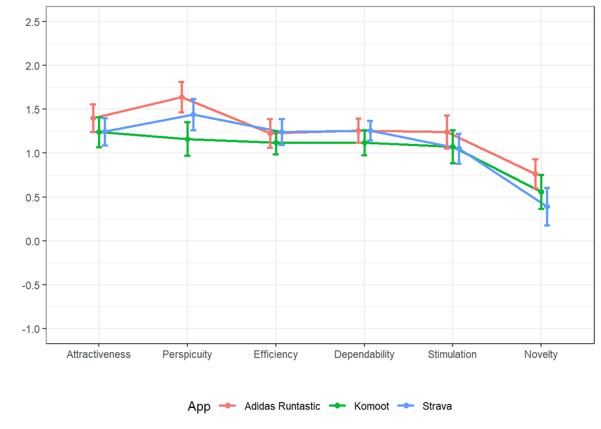

5. Save the plot in `.png` format in the designated location of your directory.
6. Looking at Figure 1 in the paper, what kind of geom(s) would you use to plot the benchmark data? Identify three obstacles for adding the benchmark data to the plot created above.

## Problem 6: Analysis of the Flow State Scale-2 Short (FSS-2S) (15 points)

1. Explain in writing why an ANOVA cannot be computed with the dataset in its current format using the approach introduced in the seminar. Then, modify the dataset in order to run the analysis.
2. Based on the modified dataset, compute the ANOVA using packages and functions introduced in the seminar. The output should look like this:

   ```
   Anova Table (Type 3 tests)

   Response: Score
     Effect          df  MSE    F   ges p.value
   1    App 1.89, 62.31 0.11 0.04 <.001    .952
   ---
   Signif. codes:  0 '***' 0.001 '**' 0.01 '*' 0.05 '+' 0.1 ' ' 1

   Sphericity correction method: GG
   ```

3. Using the documentation of the function for conducting ANOVA analyses introduced in the seminar, explain in writing how and why the output above deviates from the results reported in the paper (note that the output contains a hint). Then, change your R code so that you get the same results as in the paper.